# The Twenty Percent Border: Impact of the EU Migration and Asylum Pact

## 3 Preliminary results

**Figure 1: origin countries around the 20% cutoff**

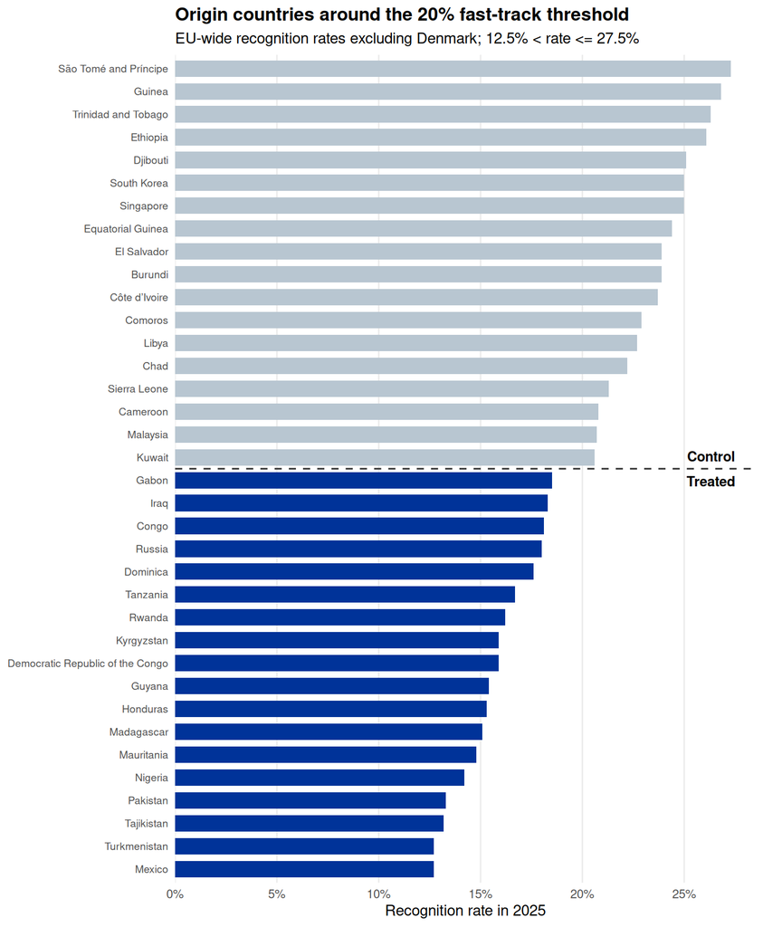

Figure 1: Origin countries around the 20% fast-track threshold

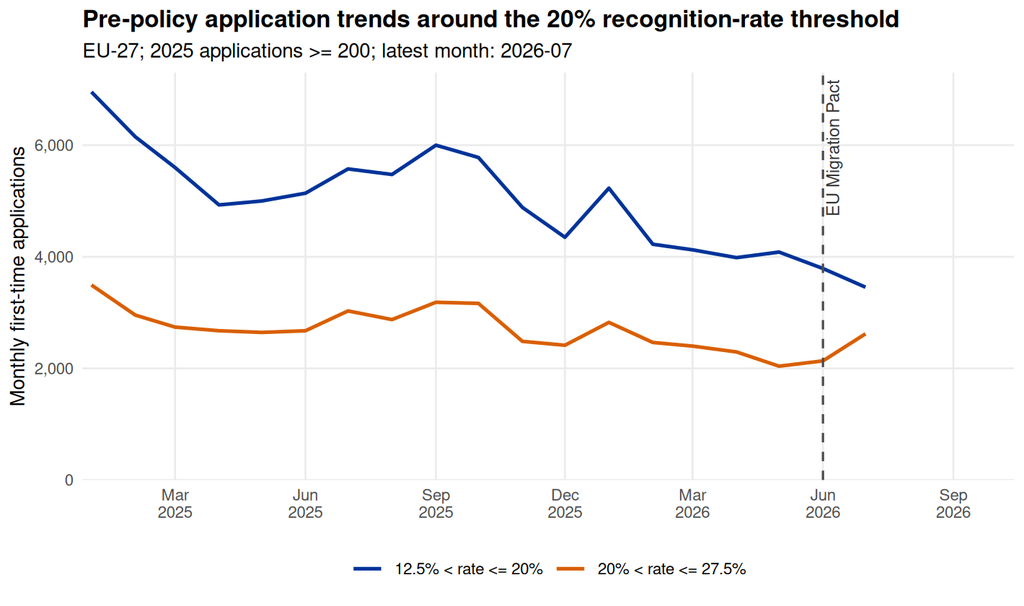

Figure 2: Monthly first-time applications by recognition-rate group

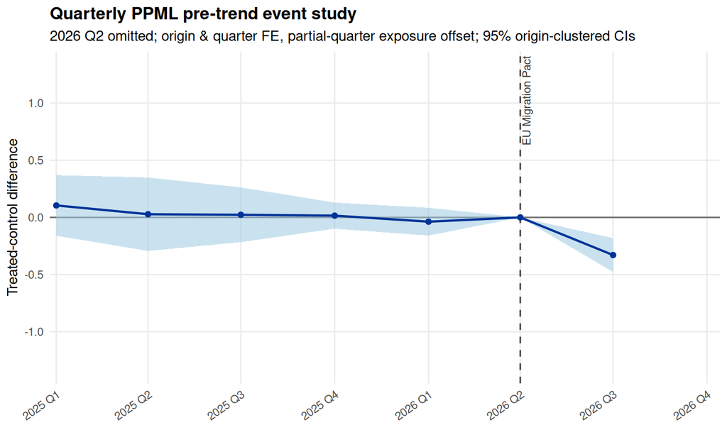

Figure 3: Quarterly PPML pre-trend event study

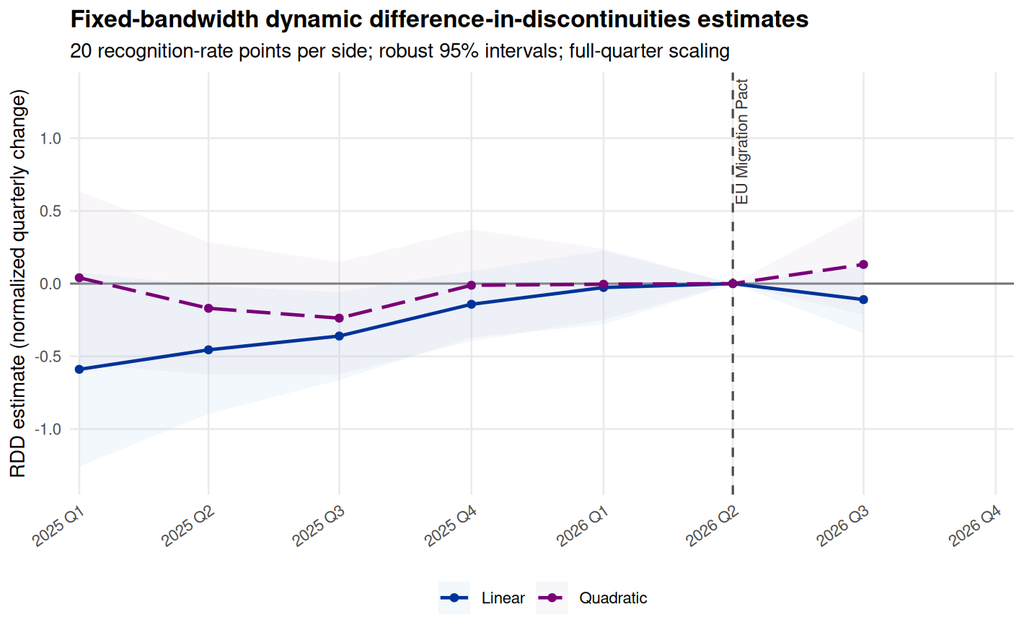

Figure 4: Fixed-bandwidth dynamic difference-in-discontinuities estimates

**Explainer: what’s behind Figure 4 (the local RDD fits)**

Each panel of the figure below is one quarterly horizon’s cutoff comparison: origin-level normalized changes plotted against the 2025 recognition rate, with application-weighted bins and the triangular-kernel linear/quadratic fits that Figure 4 summarizes into a single treated-minus-control estimate per quarter. It’s the diagnostic view behind the headline numbers, useful for checking that no single origin or outlier is driving a quarter’s estimate.

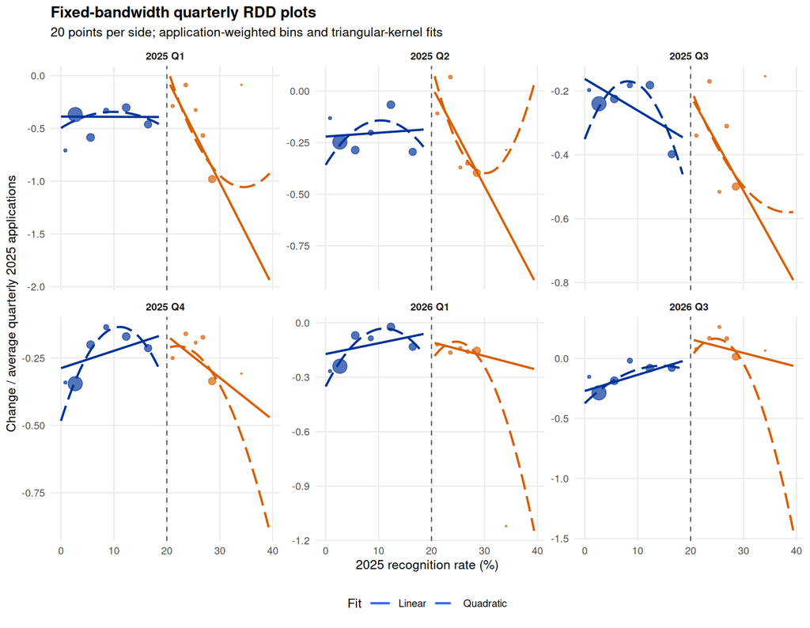

Figure 5: Fixed-bandwidth quarterly RDD plots underlying Figure 4

Figure 6 zooms in on two periods: the last quarter before the Pact (2026 Q1) and the latest data after it (July 2026), with linear fits only. Each is compared with 2026 Q2, the quarter in which the Pact took effect; an incomplete quarter is labelled by the months it covers and scaled to a full-quarter equivalent. The outcome is the same as in Figure 5. The dotted lines are the application-weighted mean change on each side of the cutoff across the full 20-point bandwidth, so the gap between them compares all treated with all control origins in the bandwidth, much like a simple first difference. The gap between the two solid lines at 20% is the RDD estimate, which uses only the variation close to the cutoff.

In 2026 Q1, the treated-side mean is -0.16 and the control-side mean -0.16, and the linear RDD estimate is -0.03 (95% CI -0.28 to 0.23). Just before the Pact, the side means differ by 0.00 and the fits show essentially no jump at the cutoff. (For pre-policy quarters the change is signed reference minus horizon, as in Figure 5.) In July 2026, the treated-side mean is -0.20 against 0.08 on the control side, so treated origins as a group lost applications relative to control origins. The linear RDD estimate is much smaller, -0.11 (95% CI -0.34 to 0.12). In the data through 2026-07, the treated-side decline is largest among origins with recognition rates far below 20%, and the treated-side fit rises toward the cutoff. The gap in means therefore reflects how treated and control origins differ in general more than a jump at the threshold itself. One post-policy month is too little to tell these apart.

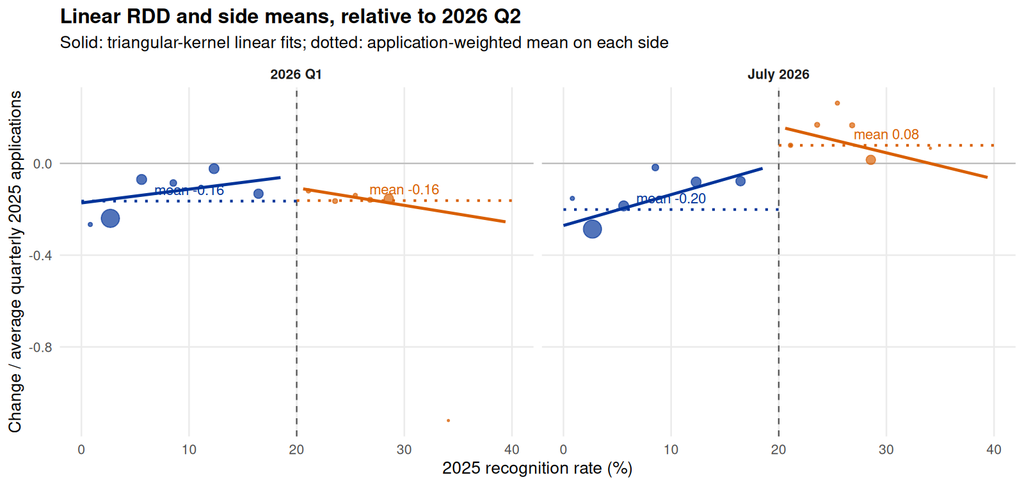

Figure 6: Linear RDD fits and side means for the last pre-policy quarter and the latest post-policy data